# STAT 542 / CS 598: Homework 4

Pushpit Saxena (netid: pushpit2)

## Question 1 Tuning Random Forests in Virtual Twins

### Data Loading:

```r
# Reading the data file
df <- read.csv(file="./Sepsis.csv", header = TRUE, sep = ",", row.names = 1)
```

### Randomly split the data into training and testing set:

- Using the sample function to split the data into test and train set. Kept the default **splitRatio = 0.75**. Also, this method with generate training data for **THERAPY == 1** and **THERAPY == 0**

```r
# Method to split the data into test and train set
test_train_split <- function(df, splitRatio=0.75) {
  train <- sample(nrow(df), splitRatio*nrow(df), replace = FALSE)
  trainSet <- df[train,]
  testSet <- df[-train, ]
  trainData_0 <- trainSet[trainSet$THERAPY == 0,]
  trainData_1 <- trainSet[trainSet$THERAPY == 1,]
  return(list("all_train" = trainSet, "train_0" = trainData_0, "train_1"=trainData_1, "test" = testSet))
}
```

### Function to train/test a virtual twin randomForest model

- In this function I have used **randomForest** library to build two RandomForest regression models (one for training data with THERAPY == 1 and other for THERAPY == 0) and then use the health prediction done by these two models for test data to predict BEST outcome for each of the record.

```r
runTwinRF <- function(train_0, train_1, test, mtryVal, nodeSizeVal) {
  set.seed(17)
  rf_0 <- randomForest(Health ~ ., data=train_0[-which(names(df) %in% c("THERAPY", "BEST"))],  mtry=mtryVal, nodesize=nodeSizeVal)
  pred_0 <- predict(rf_0, newdata = test[-which(names(df) %in% c("THERAPY", "BEST"))])
  mse_0 = mean((pred_0 - test$Health)^2)

  set.seed(17)
  rf_1 <- randomForest(Health ~ ., data=train_1[-which(names(df) %in% c("THERAPY", "BEST"))], mtry=mtryVal, nodesize=nodeSizeVal)
  pred_1 <- predict(rf_1, newdata = test[-which(names(df) %in% c("THERAPY", "BEST"))])
  mse_1 <- mean((pred_1 - test$Health)^2)

  predFinal = rep(1, nrow(test))
  predFinal[which(pred_0 >= pred_1)] = 0
  accuracy = length(which(predFinal == test$BEST))/nrow(test)
  error = length(which(predFinal != test$BEST))/nrow(test)
  return (list("accuracy" = accuracy, "error" = error, "mse_0" = mse_0, "mse_1" = mse_1, "finalPred" = predFinal))
}
```

### Grid Search for **mtry** and **nodesize**

- This is a search to figure out the 3 mtry and 3 nodesize values. I have tried mtry values in [1:(p=11)] and nodeSize = [1:50].
  - Generated 10 different split of the data, train and test virtual twin model and record the accuracy (correct prediction of BEST/no. of records in testSet)
  - Picked the best 3 mtry (7, 9, 4) and 3 nodeSize (43, 48, 50) for 100 iterations simulation
  - I have commented out this code as it takes a long to run.

### Running the 100 iterations:

```r
set.seed(13)
mtry <- c(7, 9, 4)
nodeSize <- c(43, 48, 50)
predictionError <- data.frame("Iteration" = numeric(0), "Mtry" = numeric(0), "NodeSize" = numeric(0), "Error" = numeric(0), "Accuracy" = numeric(0),"MSE_0" = numeric(0), "MSE_1" = numeric(0))
set.seed(13)
for (i in 1:100) {
  allData <- test_train_split(df)
  for (m in mtry) {
    for (n in nodeSize) {
      res <- runTwinRF(train_0=allData$train_0, train_1=allData$train_1, allData$test, m, n)
      predictionError <- rbind(predictionError,setNames(as.list(c(i,m,n, res$error, res$accuracy, res$mse_0, res$mse_1)), names(predictionError)))
    }
  }
  # cat("Done: ", i, "\n")
}

dd <- as.data.frame(predictionError %>%
  group_by(Mtry, NodeSize) %>%
  summarize(AccuracyAvgOver100Iteration = mean(Accuracy), MSE_0_Avg = mean(MSE_0), MSE_1_Avg=mean(MSE_1)))
dd[with(dd, order(-AccuracyAvgOver100Iteration)), -c(4,5)]
```

|  | Mtry | NodeSize | AccuracyAvgOver100Iteration |
| --- | --- | --- | --- |
| 9 | 9 | 50 | 0.8118644 |
| 6 | 7 | 50 | 0.8116949 |
| 5 | 7 | 48 | 0.8104237 |
| 8 | 9 | 48 | 0.8104237 |
| 7 | 9 | 43 | 0.8083051 |
| 4 | 7 | 43 | 0.8061864 |
| 2 | 4 | 48 | 0.8026271 |
| 3 | 4 | 50 | 0.8026271 |
| 1 | 4 | 43 | 0.7999153 |

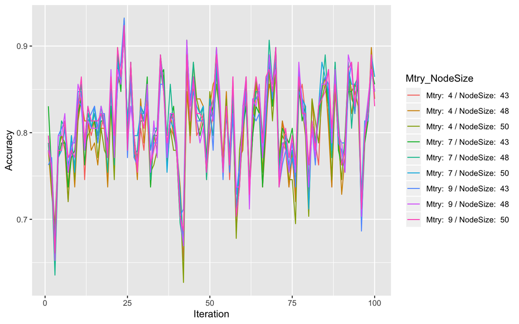

```r
library(ggplot2)
library(reshape2)
predictionError$Mtry_NodeSize <- paste("Mtry: ", predictionError$Mtry, "/ NodeSize: ", predictionError$NodeSize)
ggplot(predictionError, aes(x=Iteration, y = Accuracy, color=Mtry_NodeSize)) + geom_line()
```

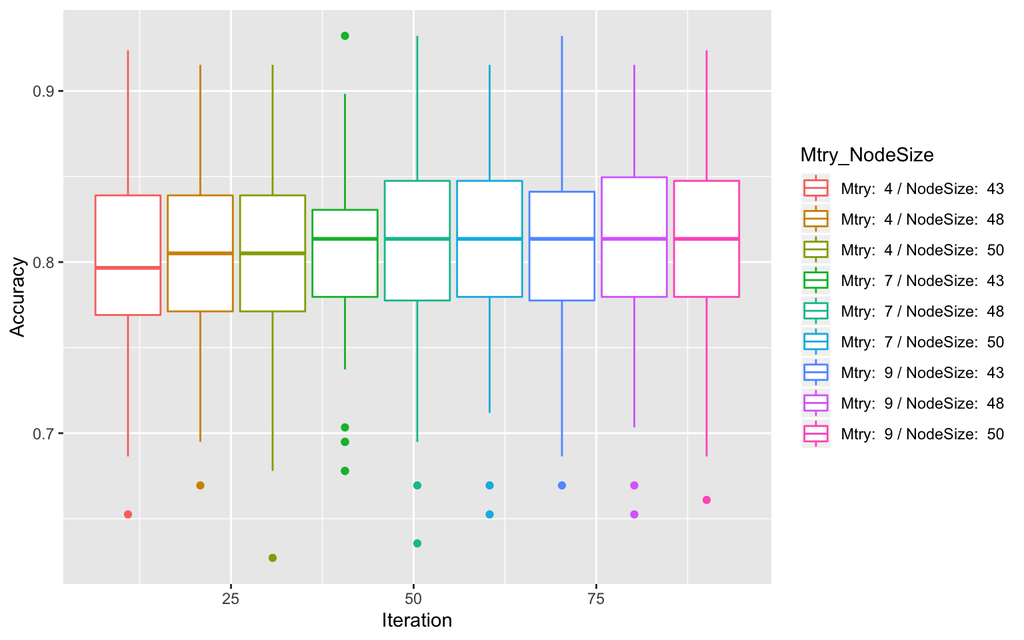

```r
ggplot(predictionError, aes(x=Iteration, y = Accuracy, color=Mtry_NodeSize)) + geom_boxplot()
```

## Question 2 [30 Points] Second Step in Virtual Twins

```r
set.seed(17)
train_0 = df[df$THERAPY == 0,]
train_1 = df[df$THERAPY == 1,]
allRf <- runTwinRF(train_0 = train_0 , train_1=train_1, df, 9, 48)
```

```r
length(which(allRf$finalPred == df$BEST))/nrow(df)
```

```
## [1] 0.8404255
```

### Fiting a single tree model (CART) on the best treatment (predicted by Optimal param virtual twin model) as outcome:

- I have used the **rpart** and **rpart.plot** library here to fit/train a single tree model and to prune it.

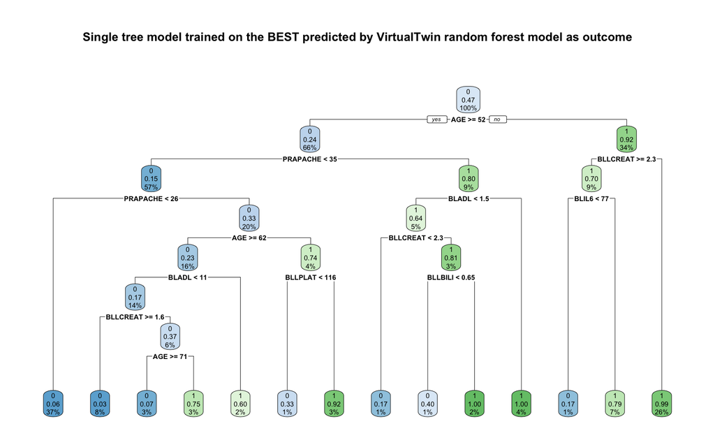

```r
new_df <- df
new_df['outcome'] = allRf$finalPred
library(rpart.plot)

# Building a single tree model
set.seed(13)
sTree <- rpart(outcome ~ ., data=new_df[-which(names(new_df) %in% c("THERAPY", "BEST", "Health"))], method = "class",
               control=rpart.control(minsplit=15, cp=0.001) )
rpart.plot(sTree, main="Single tree model trained on the BEST predicted by VirtualTwin random forest model as outcome")
```

```r
tree_pred <- predict(sTree, newdata = new_df[-which(names(df) %in% c("THERAPY", "BEST", "Health"))])
final_pred_tree <- argmax(tree_pred) - 1
```

- Single Tree (Not pruned) accuracy:

```r
length(which(final_pred_tree == df$BEST))/nrow(df)
```

```
## [1] 0.8574468
```

- Cost Complexity Pruning/Tuning:
- For pruning the tree I am using **prune** function.
- Plot of *cp* Complexity parameter

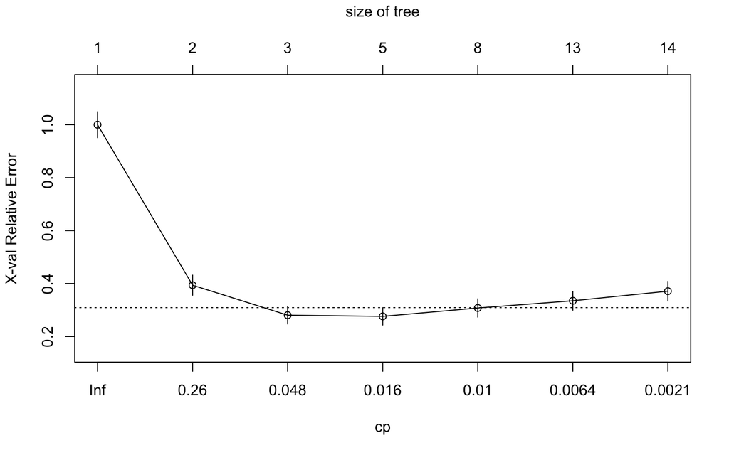

```r
plotcp(sTree)
```

- Values of **cp** as obtained from single tree model fitted before:

```r
printcp(sTree)
```

```
##
## Classification tree:
## rpart(formula = outcome ~ ., data = new_df[-which(names(new_df) %in%
##     c("THERAPY", "BEST", "Health"))], method = "class", control = rpart.control(minsplit = 15,
##     cp = 0.001))
##
## Variables actually used in tree construction:
## [1] AGE      BLADL    BLIL6    BLLBILI  BLLCREAT BLLPLAT  PRAPACHE
##
## Root node error: 221/470 = 0.47021
##
## n= 470
##
##          CP nsplit rel error  xerror     xstd
## 1 0.6063348      0   1.00000 1.00000 0.048961
## 2 0.1131222      1   0.39367 0.39367 0.038099
## 3 0.0203620      2   0.28054 0.28054 0.033196
## 4 0.0120664      4   0.23982 0.27602 0.032967
## 5 0.0090498      7   0.20362 0.30769 0.034509
## 6 0.0045249     12   0.15837 0.33484 0.035729
## 7 0.0010000     13   0.15385 0.37104 0.037229
```

- Using the value of **cp** which minimizes error to prune the single tree model:

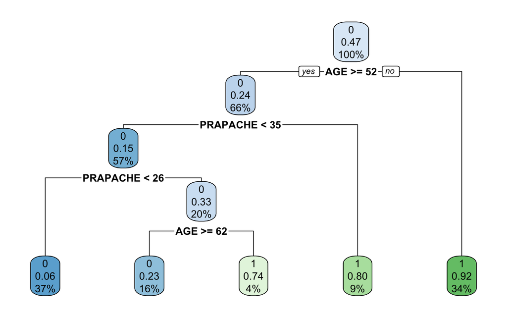

```r
set.seed(17)
pfit<- prune(sTree, cp=sTree$cptable[which.min(sTree$cptable[,"xerror"]),"CP"])
tree_pred <- predict(pfit, newdata = new_df[-which(names(df) %in% c("THERAPY", "BEST", "Health"))])
final_pred_tree <- argmax(tree_pred) - 1
rpart.plot(pfit)
```

- Accuracy of predictions done on Pruned tree:

```r
length(which(final_pred_tree == df$BEST))/nrow(df)
```

```
## [1] 0.8680851
```